# Fitness Tracker Analysis

Ozan Tivriz

2025-11-06

This is an analysis of user activity data collected from a fitness tracker application. The goal of this analysis is to understand patterns in users’ physical activity, such asexercise duration, calories burned, and heart rate, and to identify trends that may differ between various activity types (e.g., running, walking, cycling). By examining these patterns, the analysis aims to provide insights into users’ fitness behavior and help improve personalized recommendations for healthier lifestyles.

## Importing Data

```r
library(tidyverse)
library(reshape2)
```

And importing the data.

```r
trackings <- read.csv("fitness_tracker_dataset/random_fitness_dataset.csv")
```

## Cleaning

After checking the data, we see that there is not that much of a cleaning left. But it could be better so we create a new copy of our data to avoid unreversable changes.

```r
trackings_v2 <- trackings
```

Changing data type of timestamp column and adding few new columns for anaylsis

```r
trackings_v2$timestamp <- ymd_hms(trackings_v2$timestamp, tz = "UTC")

trackings_v2$day_of_week <- format(as.Date(trackings_v2$timestamp), "%A")
trackings_v2$time <- as.POSIXct(format(trackings_v2$timestamp, "%H:%M"),format="%H:%M")
```

Creating vector for day of week.

```r
days <- c("Monday", "Tuesday", "Wednesday", "Thursday", "Friday", "Saturday", "Sunday")
trackings_v2$day_of_week <- factor(trackings_v2$day_of_week, levels = days)
```

And adding a calculated column to make some anaylsis easier.

```r
trackings_v2$cal_per_min <- round(trackings_v2$calories_burned/trackings_v2$duration_min, 0)
```

If we check the cal_per_min column we see some values that is impossible for humans.

```r
max(trackings_v2$cal_per_min)
```

```
## [1] 75
```

We have to filter the data for accurate analysis. We will consider 30 calories per minute as the humanly possible limit.

```r
trackings_v2 <- trackings_v2 %>%
  filter(cal_per_min < 30)
```

We also create many different data frames but for the purpos of readability, I will not include all of them. Here is an example one of them.

```r
mean_activity <- trackings_v2 %>%
  group_by(activity_type) %>%
  summarise(
    mean_duration = mean(duration_min),
    med_duration = median(duration_min)
  )
```

I also create a data frame for correlation analysis.

```r
cor_df <- trackings_v2 %>%
  select(age,heart_rate_avg,calories_burned,duration_min)

cor_df <- cor_df %>%
  rename(Age  = age,
         HeartRate = heart_rate_avg,
         Calories = calories_burned,
         Duration = duration_min)
```

## Analysis

Here we see mean and median duration time for each activity type.

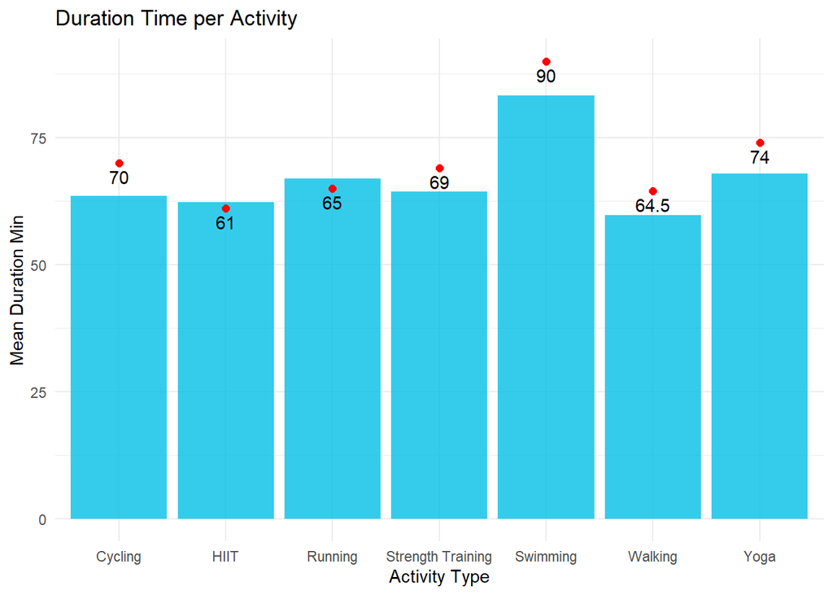

And mean and median calories burned for each activity type.

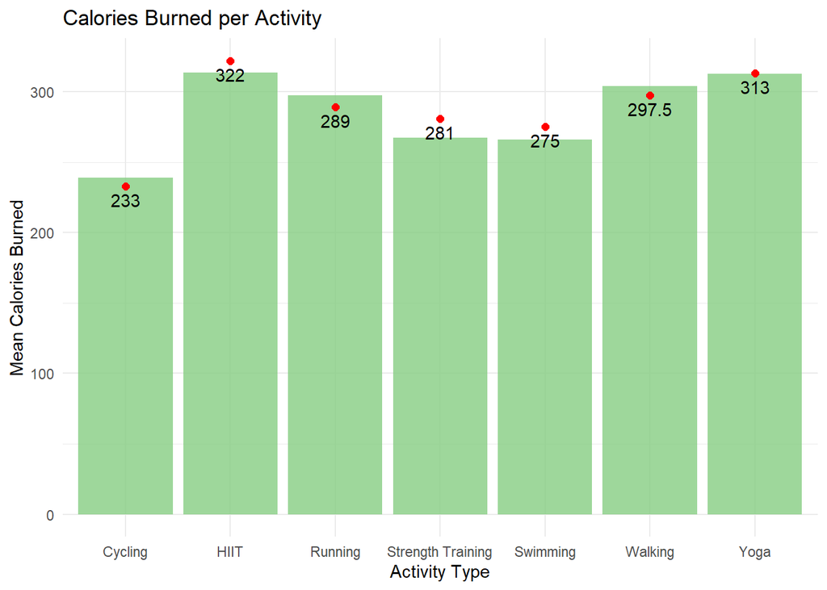

In here, we see callories burned per min by activity.

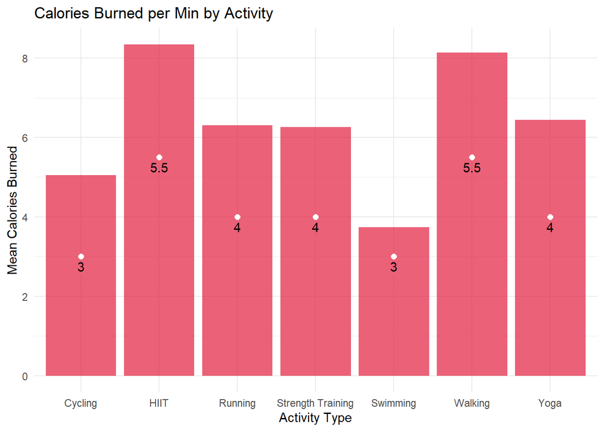

Mean and meadian ages for each activity type.

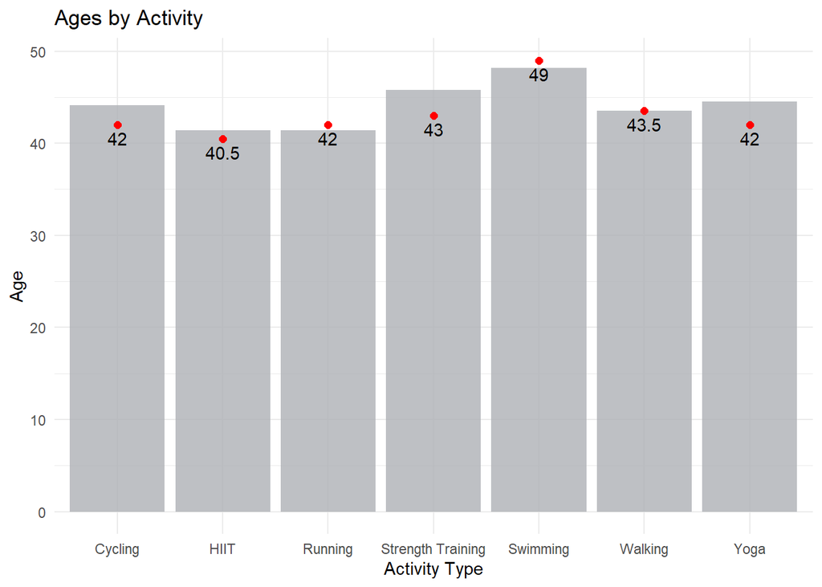

This chart shows how each activity is distributed across the days of the week.

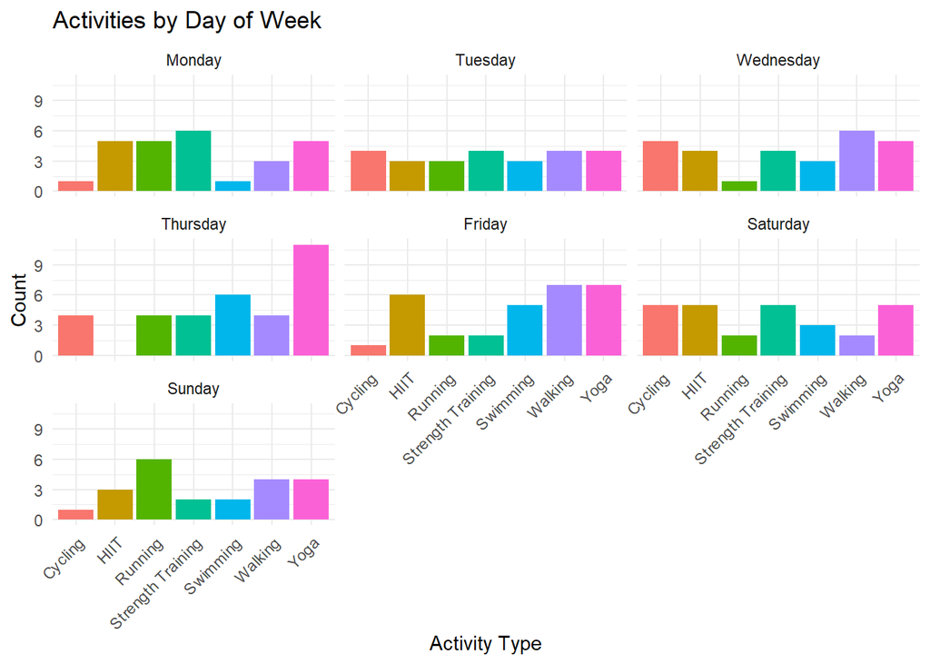

Relationship between age and average heart rate for each activity type.

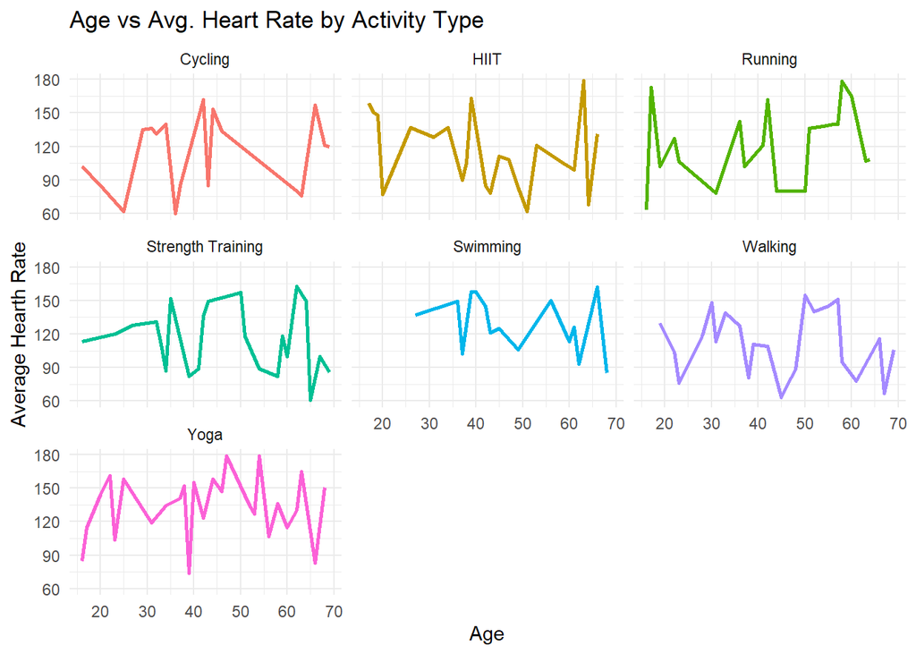

This code block shows us if there is any correlations between age, hearth rate, calories and duration. We created an data frame in background that only includes age, hearth rate, calories and duration column and named it cor_df. Also we see that there is low correlation between these 4.

```r
cor(cor_df, use = "complete.obs")
```

```
##                   Age   HeartRate    Calories   Duration
## Age        1.00000000 -0.02932592  0.01829413 0.12026338
## HeartRate -0.02932592  1.00000000 -0.06543351 0.15161175
## Calories   0.01829413 -0.06543351  1.00000000 0.05131327
## Duration   0.12026338  0.15161175  0.05131327 1.00000000
```

We melt the correlation data frame for easier interpretation.

```r
melted_cor <- melt(cor(cor_df[,c("Age","HeartRate","Calories","Duration")],
                       use = "complete.obs"))
```

This heatmap shows the correlations between age, heart rate, calories and duration.

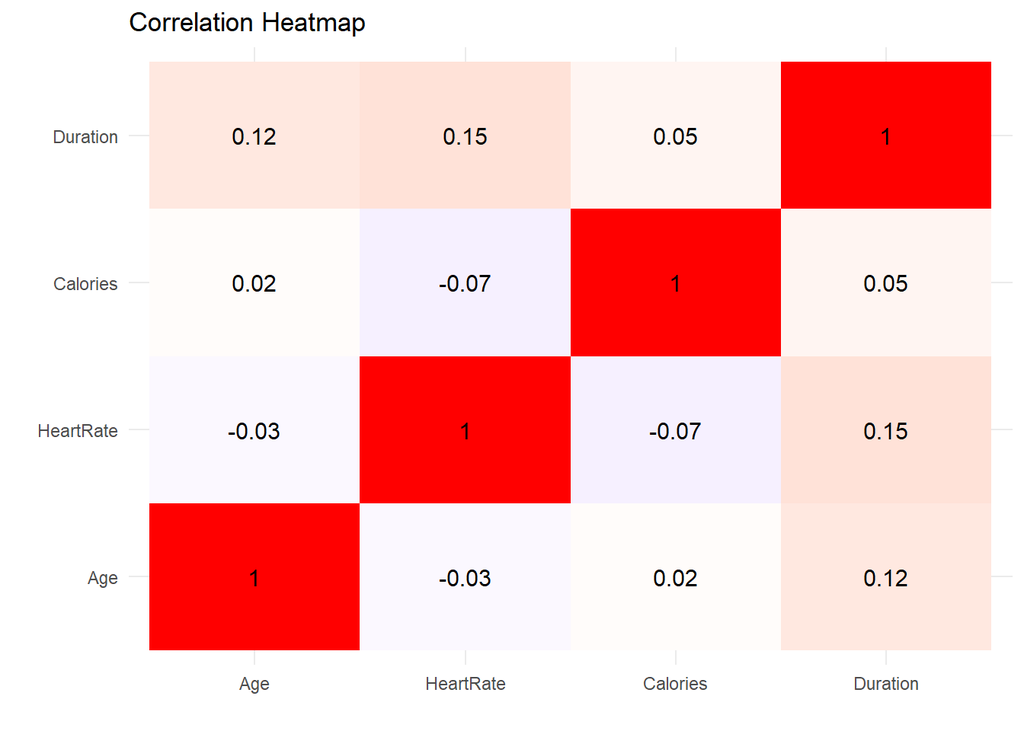

Also a comparison by gender.

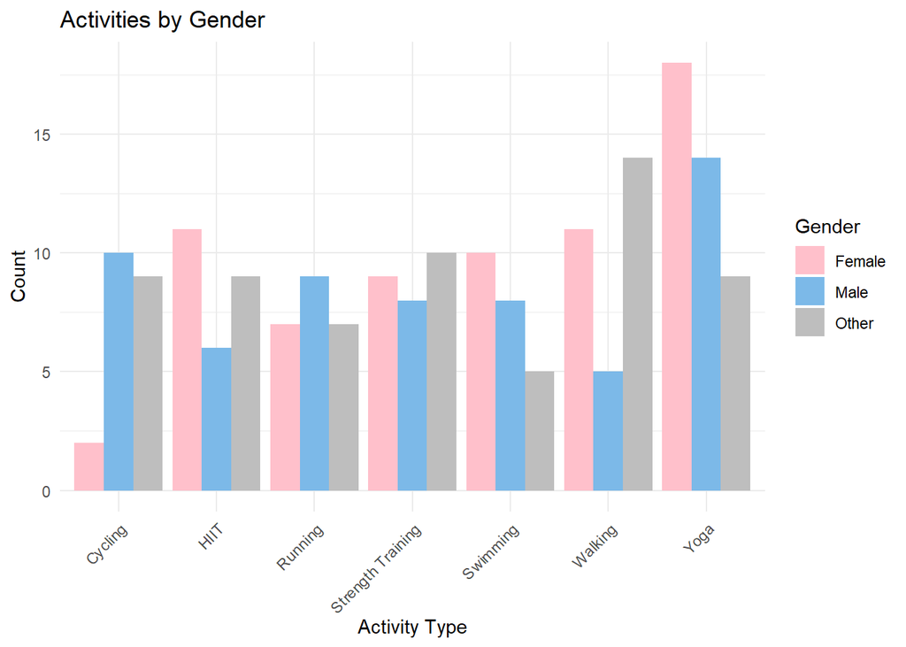

And the pie chart that shows the top activity for each gender.

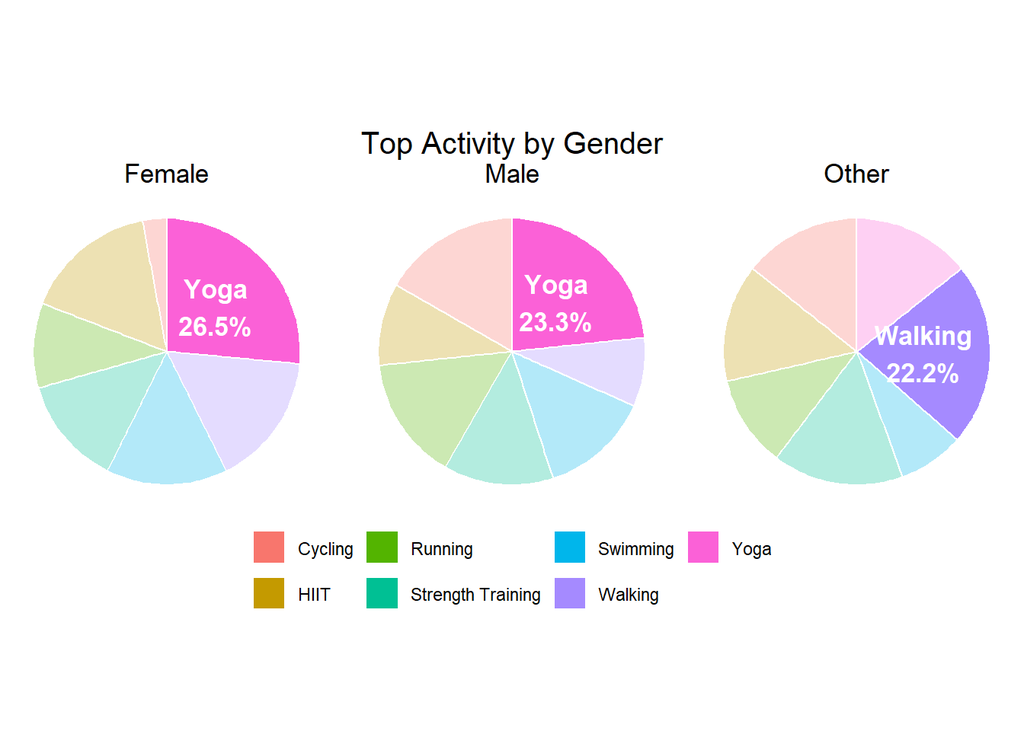

Also the pie chart that shows the least activity for each gender.

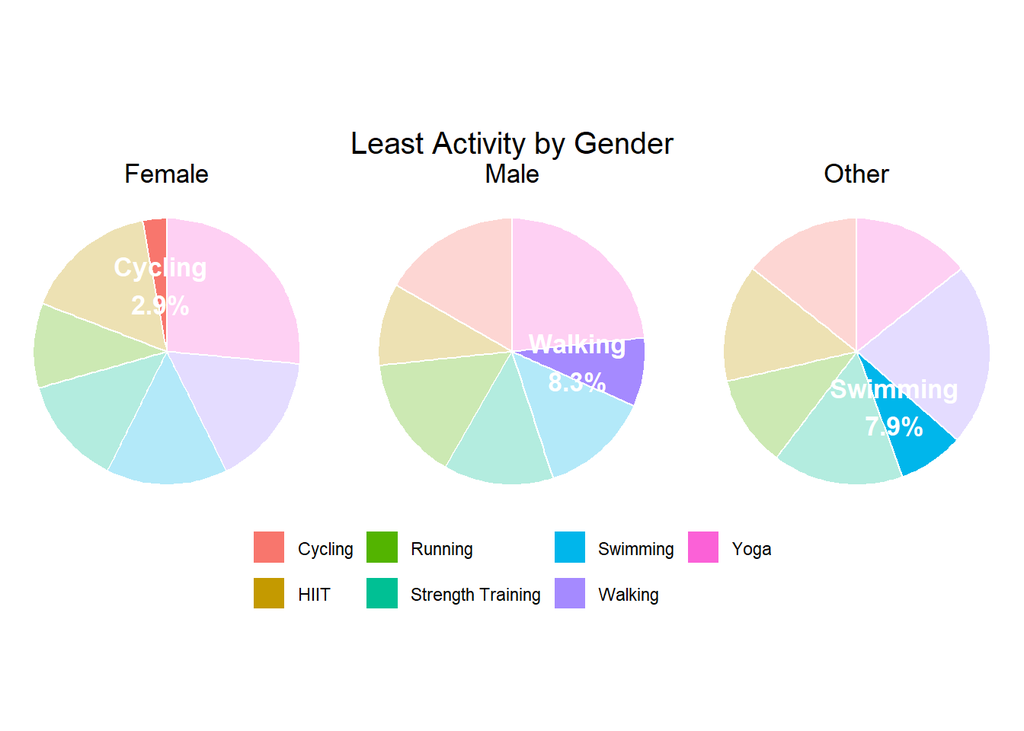

## Conclusion

*Swimming is the most time spend activity.

*HIIT burns calories the most.

*Older people are more like to do swimming activity.

*There is not much relations between day of week and activity.

*There is almost to none correlation between age, heart rate, calories burned and duration.

*Yoga is the most popular activity in both male and female.

*Cycling is the least common activity among females, walking among males,and swimming among others.